# **THE R PROGRAMMING ASSIGNMENT**

GLORIA NAKABIRI

2023-11-12

# DATA EXPLORATION 1

## Importing metaFile.csv into R.

```r
meta_File <- read.csv("metaFile.csv", header = TRUE, sep = ",")
knitr::kable(meta_File, align = "lcc")
```

| sample_id | Participant | Treatment |
| --- | --- | --- |
| sample_1 | C | 4 |
| sample_2 | B | 3 |
| sample_3 | B | 2 |
| sample_4 | C | 1 |
| sample_5 | C | 3 |
| sample_6 | A | 4 |
| sample_7 | B | 0 |
| sample_8 | A | 1 |
| sample_9 | B | 4 |
| sample_10 | C | 0 |
| sample_11 | A | 2 |
| sample_12 | A | 3 |
| sample_13 | B | 1 |
| sample_14 | C | 2 |
| sample_15 | A | 0 |
| sample_16 | C | 4 |
| sample_17 | B | 3 |
| sample_18 | B | 2 |
| sample_19 | C | 1 |
| sample_20 | C | 3 |
| sample_21 | A | 4 |
| sample_22 | B | 0 |
| sample_23 | A | 1 |
| sample_24 | B | 4 |
| sample_25 | C | 0 |
| sample_26 | A | 2 |
| sample_27 | A | 3 |
| sample_28 | B | 1 |
| sample_29 | C | 2 |
| sample_30 | A | 0 |
| sample_31 | C | 4 |
| sample_32 | B | 3 |
| sample_33 | B | 2 |
| sample_34 | C | 1 |
| sample_35 | C | 3 |
| sample_36 | A | 4 |
| sample_37 | B | 0 |
| sample_38 | A | 1 |
| sample_39 | B | 4 |
| sample_40 | C | 0 |
| sample_41 | A | 2 |
| sample_42 | A | 3 |
| sample_43 | B | 1 |
| sample_44 | C | 2 |
| sample_45 | A | 0 |
| sample_46 | C | 4 |
| sample_47 | B | 3 |
| sample_48 | B | 2 |
| sample_49 | C | 1 |
| sample_50 | C | 3 |

### The number of variables/columns and records/rows;

```r
dim(meta_File)
```

```
## [1] 50  3
```

```r
ncol(meta_File)
```

```
## [1] 3
```

```r
nrow(meta_File)
```

```
## [1] 50
```

### The number of samples which were obtained for each level of treatment;

```r
table(meta_File$Treatment)
```

```
##
##  0  1  2  3  4
##  9 10 10 11 10
```

### The number of samples which were obtained for each participant;

```r
table(meta_File$Participant)
```

```
##
##  A  B  C
## 15 17 18
```

### Records for samples obtained at treatment levels 0,2 and 4;

```r
treatment_records <- dplyr::filter(meta_File, Treatment %in% c(0, 2, 4))
knitr::kable(treatment_records, align = "lcc")
```

| sample_id | Participant | Treatment |
| --- | --- | --- |
| sample_1 | C | 4 |
| sample_3 | B | 2 |
| sample_6 | A | 4 |
| sample_7 | B | 0 |
| sample_9 | B | 4 |
| sample_10 | C | 0 |
| sample_11 | A | 2 |
| sample_14 | C | 2 |
| sample_15 | A | 0 |
| sample_16 | C | 4 |
| sample_18 | B | 2 |
| sample_21 | A | 4 |
| sample_22 | B | 0 |
| sample_24 | B | 4 |
| sample_25 | C | 0 |
| sample_26 | A | 2 |
| sample_29 | C | 2 |
| sample_30 | A | 0 |
| sample_31 | C | 4 |
| sample_33 | B | 2 |
| sample_36 | A | 4 |
| sample_37 | B | 0 |
| sample_39 | B | 4 |
| sample_40 | C | 0 |
| sample_41 | A | 2 |
| sample_44 | C | 2 |
| sample_45 | A | 0 |
| sample_46 | C | 4 |
| sample_48 | B | 2 |

### Records for samples obtained from participants A and C;

```r
participantsAC_records <- dplyr::filter(meta_File, Participant %in% c("A", "C"))
knitr::kable(participantsAC_records, align = "lcc")
```

| sample_id | Participant | Treatment |
| --- | --- | --- |
| sample_1 | C | 4 |
| sample_4 | C | 1 |
| sample_5 | C | 3 |
| sample_6 | A | 4 |
| sample_8 | A | 1 |
| sample_10 | C | 0 |
| sample_11 | A | 2 |
| sample_12 | A | 3 |
| sample_14 | C | 2 |
| sample_15 | A | 0 |
| sample_16 | C | 4 |
| sample_19 | C | 1 |
| sample_20 | C | 3 |
| sample_21 | A | 4 |
| sample_23 | A | 1 |
| sample_25 | C | 0 |
| sample_26 | A | 2 |
| sample_27 | A | 3 |
| sample_29 | C | 2 |
| sample_30 | A | 0 |
| sample_31 | C | 4 |
| sample_34 | C | 1 |
| sample_35 | C | 3 |
| sample_36 | A | 4 |
| sample_38 | A | 1 |
| sample_40 | C | 0 |
| sample_41 | A | 2 |
| sample_42 | A | 3 |
| sample_44 | C | 2 |
| sample_45 | A | 0 |
| sample_46 | C | 4 |
| sample_49 | C | 1 |
| sample_50 | C | 3 |

### The number of samples under each participant groups per treatment level;

```r
table(meta_File$Participant, meta_File$Treatment)
```

```
##
##     0 1 2 3 4
##   A 3 3 3 3 3
##   B 3 3 4 4 3
##   C 3 4 3 4 4
```

# DATA EXPLORATION 2

## Importing AssignmentFile.csv into R.

```r
assignmentfile <- read.csv("AssignmentFile.csv", header = TRUE, sep = ",")
knitr::kable(assignmentfile, align = "lrrr")
```

| samples | Conc1 | Conc2 | Conc3 |
| --- | --- | --- | --- |
| sample_1 | 5.9380487 | 2.2877765 | 3.2487625 |
| sample_2 | 3.3984629 | 4.0508845 | 3.2359883 |
| sample_3 | 1.9464752 | 1.2918230 | 1.2597982 |
| sample_4 | 1.7504377 | 4.5088147 | 2.6153558 |
| sample_5 | 2.9031939 | 2.6006057 | 1.6662130 |
| sample_6 | 0.7466299 | 3.5212946 | 1.3361532 |
| sample_7 | 2.6141261 | 1.7075223 | 2.9077324 |
| sample_8 | 2.8682325 | 0.6855859 | 0.7057831 |
| sample_9 | 4.2533269 | 1.5380970 | 4.1286548 |
| sample_10 | 2.5315286 | 1.4914619 | 2.8437762 |
| sample_11 | 2.0246913 | 1.0988479 | 3.0460737 |
| sample_12 | 1.6888849 | 1.5382037 | 1.5721820 |
| sample_13 | 0.0794829 | 1.8417749 | 5.4324201 |
| sample_14 | 2.3500216 | 2.8437762 | 3.5107200 |
| sample_15 | 2.3904181 | 4.7705793 | 2.6154821 |
| sample_16 | 0.6184972 | 2.2429638 | 2.3998393 |
| sample_17 | 2.6747861 | 3.2269440 | 1.4297713 |
| sample_18 | 1.3122641 | 3.2960420 | 3.3647171 |
| sample_19 | 1.5176821 | 2.1535883 | 1.6766006 |
| sample_20 | 0.4052203 | 2.5920906 | 3.1057814 |
| sample_21 | 2.1120733 | 3.4797040 | 0.4052203 |
| sample_22 | 1.4152211 | 3.1598762 | 1.9140865 |
| sample_23 | 2.4887630 | 2.8768958 | 2.2684174 |
| sample_24 | 1.8803341 | 3.1700562 | 2.3061025 |
| sample_25 | 1.6043019 | 3.2612428 | 1.4106253 |
| sample_26 | 2.7477339 | 2.8603185 | 3.4021108 |
| sample_27 | 3.1009269 | 3.8005525 | 3.0387250 |
| sample_28 | 1.5020081 | 0.8532958 | 2.9407410 |
| sample_29 | 0.9621180 | 1.7579986 | 2.1523931 |
| sample_30 | 2.1479188 | 1.9930619 | 4.9701923 |
| sample_31 | 2.2983576 | 1.8367984 | 3.2096464 |
| sample_32 | 1.7941053 | 1.8296990 | 2.4910030 |
| sample_33 | 2.3871712 | 1.7903664 | 4.3216649 |
| sample_34 | 2.1846347 | 1.4871950 | 2.1999546 |
| sample_35 | 1.9728277 | 3.3091355 | -0.2754937 |
| sample_36 | 1.0789328 | 2.4602617 | 3.0395745 |
| sample_37 | 2.2598966 | 3.0217533 | 2.5672832 |
| sample_38 | 4.4186806 | 3.7645799 | 2.7567790 |
| sample_39 | 2.4158240 | 3.8140188 | 2.2961438 |
| sample_40 | 1.1644263 | 3.7059658 | 3.9772471 |
| sample_41 | 2.7415788 | 3.2011782 | 3.7463223 |
| sample_42 | 2.8482647 | 2.0364330 | 2.1030553 |
| sample_43 | 3.8463786 | 1.9730300 | 3.8144462 |
| sample_44 | 3.1129542 | 3.5936637 | 1.8196195 |
| sample_45 | 1.6470471 | 4.2174458 | 3.1303307 |
| sample_46 | 2.6638029 | 2.5251532 | 3.0458905 |
| sample_47 | 1.6522736 | 2.7611225 | 0.6374504 |
| sample_48 | 2.8658576 | 2.2171705 | 2.9346651 |
| sample_49 | 2.5846741 | 3.1289636 | 1.5891398 |
| sample_50 | 1.8839943 | 2.4144523 | 2.6693480 |

### The number of variables/columns and records/rows;

```r
dim(assignmentfile)
```

```
## [1] 50  4
```

```r
ncol(assignmentfile)
```

```
## [1] 4
```

```r
nrow(assignmentfile)
```

```
## [1] 50
```

### The average concentration for each of the concetrations (ie Conc1, Conc2 and Conc3);

```r
subsetting <- assignmentfile[ , c("Conc1", "Conc2", "Conc3")]

col_average <- apply(subsetting, 2, mean)
knitr::kable(col_average, col.names = "average")
```

|  | average |
| --- | --- |
| Conc1 | 2.235910 |
| Conc2 | 2.631801 |
| Conc3 | 2.579690 |

### The average Conc for each sample (by taking the mean of Conc1, Conc2 and Conc3);

```r
averageconc_foreachsample <- apply(subsetting, 1, mean)
averageconc_foreachsample
```

```
##  [1] 3.824863 3.561779 1.499365 2.958203 2.390004 1.868026 2.409794 1.419867
##  [9] 3.306693 2.288922 2.056538 1.599757 2.451226 2.901506 3.258827 1.753767
## [17] 2.443834 2.657674 1.782624 2.034364 1.998999 2.163061 2.544692 2.452164
## [25] 2.092057 3.003388 3.313401 1.765348 1.624170 3.037058 2.448267 2.038269
## [33] 2.833067 1.957261 1.668823 2.192923 2.616311 3.646680 2.841996 2.949213
## [41] 3.229693 2.329251 3.211285 2.842079 2.998275 2.744949 1.683616 2.672564
## [49] 2.434259 2.322598
```

### Extending the data-frame by introducing a new variable say ”Concmean” to contain the average Concentration values computed above;

```r
assignmentfile$Concmean <- averageconc_foreachsample
knitr::kable(assignmentfile, align = "lrrrr")
```

| samples | Conc1 | Conc2 | Conc3 | Concmean |
| --- | --- | --- | --- | --- |
| sample_1 | 5.9380487 | 2.2877765 | 3.2487625 | 3.824863 |
| sample_2 | 3.3984629 | 4.0508845 | 3.2359883 | 3.561779 |
| sample_3 | 1.9464752 | 1.2918230 | 1.2597982 | 1.499365 |
| sample_4 | 1.7504377 | 4.5088147 | 2.6153558 | 2.958203 |
| sample_5 | 2.9031939 | 2.6006057 | 1.6662130 | 2.390004 |
| sample_6 | 0.7466299 | 3.5212946 | 1.3361532 | 1.868026 |
| sample_7 | 2.6141261 | 1.7075223 | 2.9077324 | 2.409794 |
| sample_8 | 2.8682325 | 0.6855859 | 0.7057831 | 1.419867 |
| sample_9 | 4.2533269 | 1.5380970 | 4.1286548 | 3.306693 |
| sample_10 | 2.5315286 | 1.4914619 | 2.8437762 | 2.288922 |
| sample_11 | 2.0246913 | 1.0988479 | 3.0460737 | 2.056538 |
| sample_12 | 1.6888849 | 1.5382037 | 1.5721820 | 1.599757 |
| sample_13 | 0.0794829 | 1.8417749 | 5.4324201 | 2.451226 |
| sample_14 | 2.3500216 | 2.8437762 | 3.5107200 | 2.901506 |
| sample_15 | 2.3904181 | 4.7705793 | 2.6154821 | 3.258827 |
| sample_16 | 0.6184972 | 2.2429638 | 2.3998393 | 1.753767 |
| sample_17 | 2.6747861 | 3.2269440 | 1.4297713 | 2.443834 |
| sample_18 | 1.3122641 | 3.2960420 | 3.3647171 | 2.657674 |
| sample_19 | 1.5176821 | 2.1535883 | 1.6766006 | 1.782624 |
| sample_20 | 0.4052203 | 2.5920906 | 3.1057814 | 2.034364 |
| sample_21 | 2.1120733 | 3.4797040 | 0.4052203 | 1.998999 |
| sample_22 | 1.4152211 | 3.1598762 | 1.9140865 | 2.163061 |
| sample_23 | 2.4887630 | 2.8768958 | 2.2684174 | 2.544692 |
| sample_24 | 1.8803341 | 3.1700562 | 2.3061025 | 2.452164 |
| sample_25 | 1.6043019 | 3.2612428 | 1.4106253 | 2.092057 |
| sample_26 | 2.7477339 | 2.8603185 | 3.4021108 | 3.003388 |
| sample_27 | 3.1009269 | 3.8005525 | 3.0387250 | 3.313401 |
| sample_28 | 1.5020081 | 0.8532958 | 2.9407410 | 1.765348 |
| sample_29 | 0.9621180 | 1.7579986 | 2.1523931 | 1.624170 |
| sample_30 | 2.1479188 | 1.9930619 | 4.9701923 | 3.037058 |
| sample_31 | 2.2983576 | 1.8367984 | 3.2096464 | 2.448268 |
| sample_32 | 1.7941053 | 1.8296990 | 2.4910030 | 2.038269 |
| sample_33 | 2.3871712 | 1.7903664 | 4.3216649 | 2.833067 |
| sample_34 | 2.1846347 | 1.4871950 | 2.1999546 | 1.957261 |
| sample_35 | 1.9728277 | 3.3091355 | -0.2754937 | 1.668823 |
| sample_36 | 1.0789328 | 2.4602617 | 3.0395745 | 2.192923 |
| sample_37 | 2.2598966 | 3.0217533 | 2.5672832 | 2.616311 |
| sample_38 | 4.4186806 | 3.7645799 | 2.7567790 | 3.646680 |
| sample_39 | 2.4158240 | 3.8140188 | 2.2961438 | 2.841995 |
| sample_40 | 1.1644263 | 3.7059658 | 3.9772471 | 2.949213 |
| sample_41 | 2.7415788 | 3.2011782 | 3.7463223 | 3.229693 |
| sample_42 | 2.8482647 | 2.0364330 | 2.1030553 | 2.329251 |
| sample_43 | 3.8463786 | 1.9730300 | 3.8144462 | 3.211285 |
| sample_44 | 3.1129542 | 3.5936637 | 1.8196195 | 2.842079 |
| sample_45 | 1.6470471 | 4.2174458 | 3.1303307 | 2.998274 |
| sample_46 | 2.6638029 | 2.5251532 | 3.0458905 | 2.744949 |
| sample_47 | 1.6522736 | 2.7611225 | 0.6374504 | 1.683615 |
| sample_48 | 2.8658576 | 2.2171705 | 2.9346651 | 2.672564 |
| sample_49 | 2.5846741 | 3.1289636 | 1.5891398 | 2.434259 |
| sample_50 | 1.8839943 | 2.4144523 | 2.6693480 | 2.322598 |

### The basic statistics (min, max, mean, median, quartiles, variance, standard deviation) for all the variables including Concmean;

```r
summary(assignmentfile[c("Conc1", "Conc2", "Conc3", "Concmean")])
```

```
##      Conc1             Conc2            Conc3            Concmean
##  Min.   :0.07948   Min.   :0.6856   Min.   :-0.2755   Min.   :1.420
##  1st Qu.:1.64835   1st Qu.:1.8380   1st Qu.: 1.8432   1st Qu.:2.035
##  Median :2.22227   Median :2.5963   Median : 2.6424   Median :2.446
##  Mean   :2.23591   Mean   :2.6318   Mean   : 2.5797   Mean   :2.482
##  3rd Qu.:2.72488   3rd Qu.:3.2873   3rd Qu.: 3.1898   3rd Qu.:2.937
##  Max.   :5.93805   Max.   :4.7706   Max.   : 5.4324   Max.   :3.825
```

```r
variances <- sapply(assignmentfile[c("Conc1", "Conc2", "Conc3", "Concmean")], var)
variances
```

```
##     Conc1     Conc2     Conc3  Concmean
## 1.0784026 0.9318250 1.2475056 0.3621831
```

```r
standarddevs <- sapply(assignmentfile[c("Conc1", "Conc2", "Conc3", "Concmean")], sd)
standarddevs
```

```
##     Conc1     Conc2     Conc3  Concmean
## 1.0384617 0.9653108 1.1169179 0.6018165
```

# DATA MANIPULATION AND GRAPHICS

### Removing variables Conc1, Conc2 and Conc3 from the concentration data-frame;

```r
conc_df <- assignmentfile[- c(2,3,4)]
knitr::kable(conc_df, align = "lc")
```

| samples | Concmean |
| --- | --- |
| sample_1 | 3.824863 |
| sample_2 | 3.561779 |
| sample_3 | 1.499365 |
| sample_4 | 2.958203 |
| sample_5 | 2.390004 |
| sample_6 | 1.868026 |
| sample_7 | 2.409794 |
| sample_8 | 1.419867 |
| sample_9 | 3.306693 |
| sample_10 | 2.288922 |
| sample_11 | 2.056538 |
| sample_12 | 1.599757 |
| sample_13 | 2.451226 |
| sample_14 | 2.901506 |
| sample_15 | 3.258827 |
| sample_16 | 1.753767 |
| sample_17 | 2.443834 |
| sample_18 | 2.657674 |
| sample_19 | 1.782624 |
| sample_20 | 2.034364 |
| sample_21 | 1.998999 |
| sample_22 | 2.163061 |
| sample_23 | 2.544692 |
| sample_24 | 2.452164 |
| sample_25 | 2.092057 |
| sample_26 | 3.003388 |
| sample_27 | 3.313401 |
| sample_28 | 1.765348 |
| sample_29 | 1.624170 |
| sample_30 | 3.037058 |
| sample_31 | 2.448268 |
| sample_32 | 2.038269 |
| sample_33 | 2.833067 |
| sample_34 | 1.957261 |
| sample_35 | 1.668823 |
| sample_36 | 2.192923 |
| sample_37 | 2.616311 |
| sample_38 | 3.646680 |
| sample_39 | 2.841995 |
| sample_40 | 2.949213 |
| sample_41 | 3.229693 |
| sample_42 | 2.329251 |
| sample_43 | 3.211285 |
| sample_44 | 2.842079 |
| sample_45 | 2.998274 |
| sample_46 | 2.744949 |
| sample_47 | 1.683615 |
| sample_48 | 2.672564 |
| sample_49 | 2.434259 |
| sample_50 | 2.322598 |

### Combining (merge) information in the two data-frames concentration with metadata;

```r
combined_df <- data.frame(meta_File[1:3], conc_df[2])
knitr::kable(combined_df, align = "lccr")
```

| sample_id | Participant | Treatment | Concmean |
| --- | --- | --- | --- |
| sample_1 | C | 4 | 3.824863 |
| sample_2 | B | 3 | 3.561779 |
| sample_3 | B | 2 | 1.499365 |
| sample_4 | C | 1 | 2.958203 |
| sample_5 | C | 3 | 2.390004 |
| sample_6 | A | 4 | 1.868026 |
| sample_7 | B | 0 | 2.409794 |
| sample_8 | A | 1 | 1.419867 |
| sample_9 | B | 4 | 3.306693 |
| sample_10 | C | 0 | 2.288922 |
| sample_11 | A | 2 | 2.056538 |
| sample_12 | A | 3 | 1.599757 |
| sample_13 | B | 1 | 2.451226 |
| sample_14 | C | 2 | 2.901506 |
| sample_15 | A | 0 | 3.258827 |
| sample_16 | C | 4 | 1.753767 |
| sample_17 | B | 3 | 2.443834 |
| sample_18 | B | 2 | 2.657674 |
| sample_19 | C | 1 | 1.782624 |
| sample_20 | C | 3 | 2.034364 |
| sample_21 | A | 4 | 1.998999 |
| sample_22 | B | 0 | 2.163061 |
| sample_23 | A | 1 | 2.544692 |
| sample_24 | B | 4 | 2.452164 |
| sample_25 | C | 0 | 2.092057 |
| sample_26 | A | 2 | 3.003388 |
| sample_27 | A | 3 | 3.313401 |
| sample_28 | B | 1 | 1.765348 |
| sample_29 | C | 2 | 1.624170 |
| sample_30 | A | 0 | 3.037058 |
| sample_31 | C | 4 | 2.448268 |
| sample_32 | B | 3 | 2.038269 |
| sample_33 | B | 2 | 2.833067 |
| sample_34 | C | 1 | 1.957261 |
| sample_35 | C | 3 | 1.668823 |
| sample_36 | A | 4 | 2.192923 |
| sample_37 | B | 0 | 2.616311 |
| sample_38 | A | 1 | 3.646680 |
| sample_39 | B | 4 | 2.841995 |
| sample_40 | C | 0 | 2.949213 |
| sample_41 | A | 2 | 3.229693 |
| sample_42 | A | 3 | 2.329251 |
| sample_43 | B | 1 | 3.211285 |
| sample_44 | C | 2 | 2.842079 |
| sample_45 | A | 0 | 2.998274 |
| sample_46 | C | 4 | 2.744949 |
| sample_47 | B | 3 | 1.683615 |
| sample_48 | B | 2 | 2.672564 |
| sample_49 | C | 1 | 2.434259 |
| sample_50 | C | 3 | 2.322598 |

### Checking the size of the combined data-frame and verifying it is what is expected;

```r
dim(combined_df)
```

```
## [1] 50  4
```

```r
colnames(combined_df)
```

```
## [1] "sample_id"   "Participant" "Treatment"   "Concmean"
```

```r
knitr::kable(head(combined_df), align = "lccr")
```

| sample_id | Participant | Treatment | Concmean |
| --- | --- | --- | --- |
| sample_1 | C | 4 | 3.824863 |
| sample_2 | B | 3 | 3.561779 |
| sample_3 | B | 2 | 1.499365 |
| sample_4 | C | 1 | 2.958203 |
| sample_5 | C | 3 | 2.390004 |
| sample_6 | A | 4 | 1.868026 |

### Extracting records for samples for participants B and C obtained at treatment levels 2,3 and 4 from the combined dataset; Assigning this to variable “participantsBC”

```r
participantsBC <- dplyr::filter(combined_df, Participant %in% c("B", "C")
                                & Treatment %in% c("2", "3", "4"))
knitr::kable(participantsBC, align = "lccr")
```

| sample_id | Participant | Treatment | Concmean |
| --- | --- | --- | --- |
| sample_1 | C | 4 | 3.824863 |
| sample_2 | B | 3 | 3.561779 |
| sample_3 | B | 2 | 1.499365 |
| sample_5 | C | 3 | 2.390004 |
| sample_9 | B | 4 | 3.306693 |
| sample_14 | C | 2 | 2.901506 |
| sample_16 | C | 4 | 1.753767 |
| sample_17 | B | 3 | 2.443834 |
| sample_18 | B | 2 | 2.657674 |
| sample_20 | C | 3 | 2.034364 |
| sample_24 | B | 4 | 2.452164 |
| sample_29 | C | 2 | 1.624170 |
| sample_31 | C | 4 | 2.448268 |
| sample_32 | B | 3 | 2.038269 |
| sample_33 | B | 2 | 2.833067 |
| sample_35 | C | 3 | 1.668823 |
| sample_39 | B | 4 | 2.841995 |
| sample_44 | C | 2 | 2.842079 |
| sample_46 | C | 4 | 2.744949 |
| sample_47 | B | 3 | 1.683615 |
| sample_48 | B | 2 | 2.672564 |
| sample_50 | C | 3 | 2.322598 |

### Using ”participantsBC”, computing the average Concentration for participants B and C under treatments 2, 3 and 4;

```r
library(dplyr)
participantsBC %>%
group_by(Participant, Treatment) %>%
summarise(Averageconcentration = mean(Concmean))
```

| Participant | Treatment | Averageconcentration |
| --- | --- | --- |
| B | 2 | 2.415668 |
| B | 3 | 2.431874 |
| B | 4 | 2.866951 |
| C | 2 | 2.455918 |
| C | 3 | 2.103947 |
| C | 4 | 2.692961 |

```r
#OR
aggregate(participantsBC$Concmean,
          by = list(Participant = participantsBC$Participant,
                    Treatment = participantsBC$Treatment), FUN = mean)
```

| Participant | Treatment | x |
| --- | --- | --- |
| B | 2 | 2.415668 |
| C | 2 | 2.455918 |
| B | 3 | 2.431874 |
| C | 3 | 2.103947 |
| B | 4 | 2.866951 |
| C | 4 | 2.692961 |

### Using a for loop to change treatment levels from 0,1,2,3,4 to “very-low”, “low”, “moderate”, “high”, “very-high” respectively on the combined dataset;

```r
changedcombined_df <- combined_df

for(r in 1:nrow(changedcombined_df)) {
  if(changedcombined_df[r,3] == 0) {
    changedcombined_df[r,3] <- "very-low"
  }
  else if(changedcombined_df[r,3] == 1) {
    changedcombined_df[r,3] <- "low"
  }
  else if(changedcombined_df[r,3] == 2) {
    changedcombined_df[r,3] <- "moderate"
  }
  else if(changedcombined_df[r,3] == 3) {
    changedcombined_df[r,3] <- "high"
  }
  else if(changedcombined_df[r,3] == 4) {
    changedcombined_df[r,3] <- "very-high"
  }
}

knitr::kable(changedcombined_df, align = "lccr")
```

| sample_id | Participant | Treatment | Concmean |
| --- | --- | --- | --- |
| sample_1 | C | very-high | 3.824863 |
| sample_2 | B | high | 3.561779 |
| sample_3 | B | moderate | 1.499365 |
| sample_4 | C | low | 2.958203 |
| sample_5 | C | high | 2.390004 |
| sample_6 | A | very-high | 1.868026 |
| sample_7 | B | very-low | 2.409794 |
| sample_8 | A | low | 1.419867 |
| sample_9 | B | very-high | 3.306693 |
| sample_10 | C | very-low | 2.288922 |
| sample_11 | A | moderate | 2.056538 |
| sample_12 | A | high | 1.599757 |
| sample_13 | B | low | 2.451226 |
| sample_14 | C | moderate | 2.901506 |
| sample_15 | A | very-low | 3.258827 |
| sample_16 | C | very-high | 1.753767 |
| sample_17 | B | high | 2.443834 |
| sample_18 | B | moderate | 2.657674 |
| sample_19 | C | low | 1.782624 |
| sample_20 | C | high | 2.034364 |
| sample_21 | A | very-high | 1.998999 |
| sample_22 | B | very-low | 2.163061 |
| sample_23 | A | low | 2.544692 |
| sample_24 | B | very-high | 2.452164 |
| sample_25 | C | very-low | 2.092057 |
| sample_26 | A | moderate | 3.003388 |
| sample_27 | A | high | 3.313401 |
| sample_28 | B | low | 1.765348 |
| sample_29 | C | moderate | 1.624170 |
| sample_30 | A | very-low | 3.037058 |
| sample_31 | C | very-high | 2.448268 |
| sample_32 | B | high | 2.038269 |
| sample_33 | B | moderate | 2.833067 |
| sample_34 | C | low | 1.957261 |
| sample_35 | C | high | 1.668823 |
| sample_36 | A | very-high | 2.192923 |
| sample_37 | B | very-low | 2.616311 |
| sample_38 | A | low | 3.646680 |
| sample_39 | B | very-high | 2.841995 |
| sample_40 | C | very-low | 2.949213 |
| sample_41 | A | moderate | 3.229693 |
| sample_42 | A | high | 2.329251 |
| sample_43 | B | low | 3.211285 |
| sample_44 | C | moderate | 2.842079 |
| sample_45 | A | very-low | 2.998274 |
| sample_46 | C | very-high | 2.744949 |
| sample_47 | B | high | 1.683615 |
| sample_48 | B | moderate | 2.672564 |
| sample_49 | C | low | 2.434259 |
| sample_50 | C | high | 2.322598 |

### Writing a function to change treatment levels from 0,1,2,3,4 to ”very-low”, ”low”,”moderate”, ”high”, ”very-high” respectively, using this with sapply() to change treatment variable in combined dataset;

```r
func_changeddf <- combined_df

labelchanges <- function(n) {
  if(n == 0) {
    return("very-low")
  }
  else if(n == 1) {
    return("low")
  }
  else if(n == 2) {
    return("moderate")
  }
  else if(n == 3) {
    return("high")
  }
  else if(n == 4) {
    return("very-high")
  }
}

func_changeddf$Treatment <- sapply(func_changeddf$Treatment, labelchanges)
knitr::kable(func_changeddf, align = "lccr")
```

| sample_id | Participant | Treatment | Concmean |
| --- | --- | --- | --- |
| sample_1 | C | very-high | 3.824863 |
| sample_2 | B | high | 3.561779 |
| sample_3 | B | moderate | 1.499365 |
| sample_4 | C | low | 2.958203 |
| sample_5 | C | high | 2.390004 |
| sample_6 | A | very-high | 1.868026 |
| sample_7 | B | very-low | 2.409794 |
| sample_8 | A | low | 1.419867 |
| sample_9 | B | very-high | 3.306693 |
| sample_10 | C | very-low | 2.288922 |
| sample_11 | A | moderate | 2.056538 |
| sample_12 | A | high | 1.599757 |
| sample_13 | B | low | 2.451226 |
| sample_14 | C | moderate | 2.901506 |
| sample_15 | A | very-low | 3.258827 |
| sample_16 | C | very-high | 1.753767 |
| sample_17 | B | high | 2.443834 |
| sample_18 | B | moderate | 2.657674 |
| sample_19 | C | low | 1.782624 |
| sample_20 | C | high | 2.034364 |
| sample_21 | A | very-high | 1.998999 |
| sample_22 | B | very-low | 2.163061 |
| sample_23 | A | low | 2.544692 |
| sample_24 | B | very-high | 2.452164 |
| sample_25 | C | very-low | 2.092057 |
| sample_26 | A | moderate | 3.003388 |
| sample_27 | A | high | 3.313401 |
| sample_28 | B | low | 1.765348 |
| sample_29 | C | moderate | 1.624170 |
| sample_30 | A | very-low | 3.037058 |
| sample_31 | C | very-high | 2.448268 |
| sample_32 | B | high | 2.038269 |
| sample_33 | B | moderate | 2.833067 |
| sample_34 | C | low | 1.957261 |
| sample_35 | C | high | 1.668823 |
| sample_36 | A | very-high | 2.192923 |
| sample_37 | B | very-low | 2.616311 |
| sample_38 | A | low | 3.646680 |
| sample_39 | B | very-high | 2.841995 |
| sample_40 | C | very-low | 2.949213 |
| sample_41 | A | moderate | 3.229693 |
| sample_42 | A | high | 2.329251 |
| sample_43 | B | low | 3.211285 |
| sample_44 | C | moderate | 2.842079 |
| sample_45 | A | very-low | 2.998274 |
| sample_46 | C | very-high | 2.744949 |
| sample_47 | B | high | 1.683615 |
| sample_48 | B | moderate | 2.672564 |
| sample_49 | C | low | 2.434259 |
| sample_50 | C | high | 2.322598 |

### Checking and commenting on the time taken to perform the above two operations using the for loop and sapply();

```r
forloop_time <- system.time(for(r in 1:nrow(changedcombined_df)) {
  if(changedcombined_df[r,3] == 0) {
    changedcombined_df[r,3] <- "very-low"
  }
  else if(changedcombined_df[r,3] == 1) {
    changedcombined_df[r,3] <- "low"
  }
  else if(changedcombined_df[r,3] == 2) {
    changedcombined_df[r,3] <- "moderate"
  }
  else if(changedcombined_df[r,3] == 3) {
    changedcombined_df[r,3] <- "high"
  }
  else if(changedcombined_df[r,3] == 4) {
    changedcombined_df[r,3] <- "very-high"
  }
})
forloop_time
```

```
##    user  system elapsed
##    0.02    0.00    0.03
```

```r
sapply_time <- system.time(
  func_changeddf$Treatment <- sapply(func_changeddf$Treatment, labelchanges))
sapply_time
```

```
##    user  system elapsed
##       0       0       0
```

#### Comment

*The sapply() takes a shorter time frame than the for loop to change the treatment levels.*

### Using ggplot2 package, produce appropriate graphical representation of the combined dataset with the changed treatment levels;

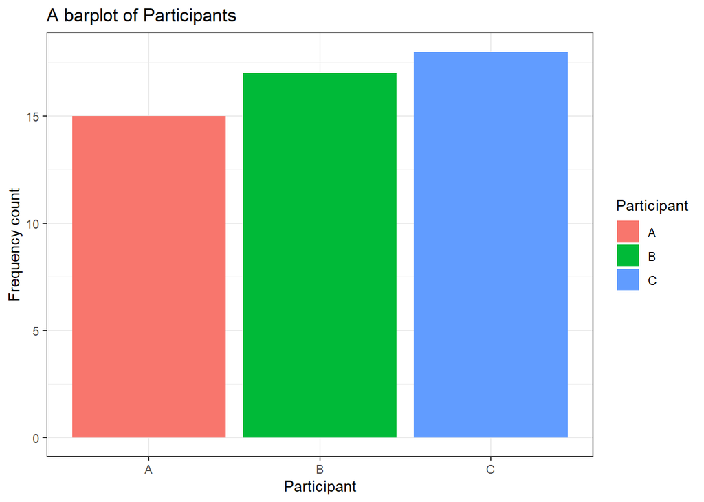

```r
##plotting graphs
library(ggplot2)
Graph1 <- ggplot(data = changedcombined_df,
                 mapping = aes(x = Participant, fill = Participant)) +
  geom_bar() + theme_bw() +
  labs(title = "A barplot of Participants",
       x = "Participant", y = "Frequency count")
Graph1
```

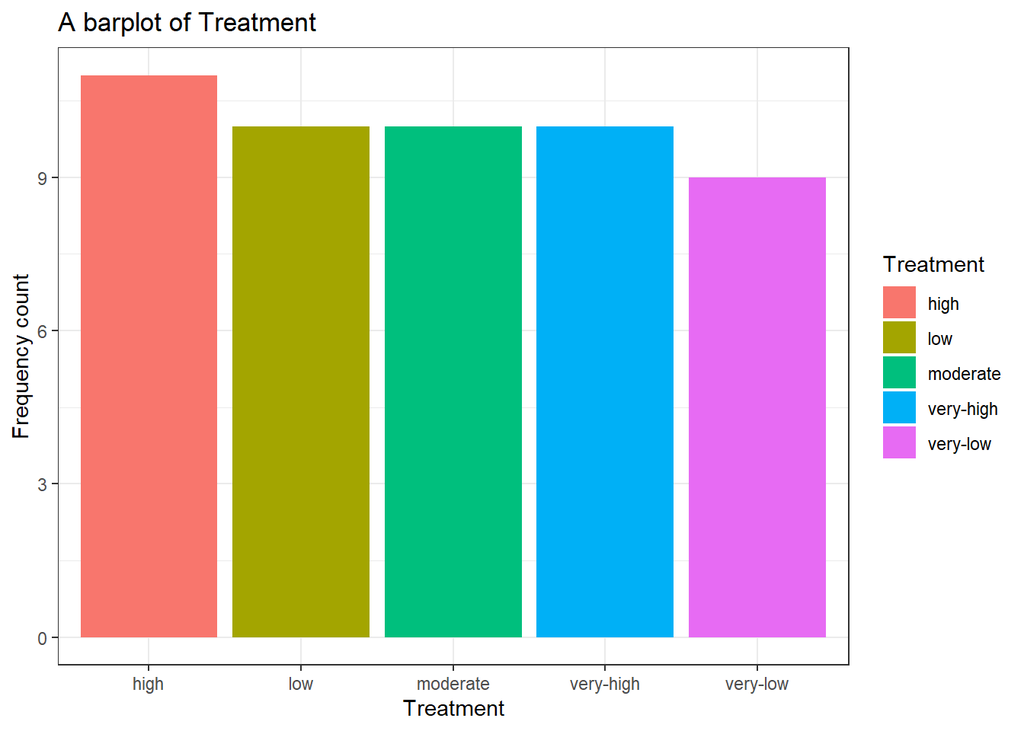

```r
Graph2 <- ggplot(data = changedcombined_df,
                 mapping = aes(x = Treatment, fill = Treatment)) +
  geom_bar() + theme_bw() + labs(title = "A barplot of Treatment",
                                 x = "Treatment", y = "Frequency count")
Graph2
```

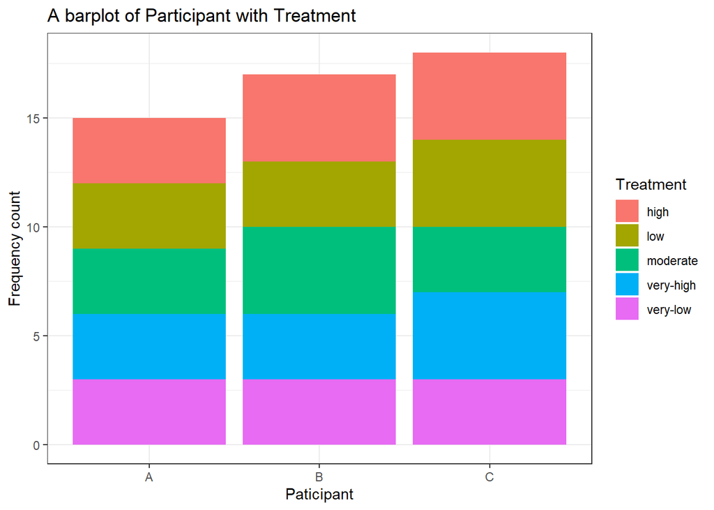

```r
Graph3 <- ggplot(data = changedcombined_df,
                 mapping = aes(x = Participant, fill = Treatment)) +
  geom_bar() + theme_bw() +
  labs(title = "A barplot of Participant with Treatment",
       x = "Paticipant", y = "Frequency count")
Graph3
```

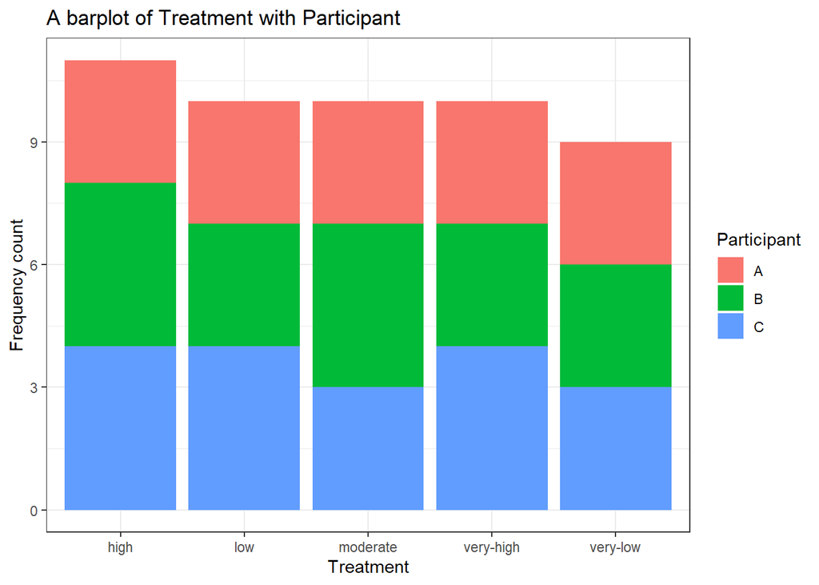

```r
Graph4 <- ggplot(data = changedcombined_df,
                 mapping = aes(x = Treatment, fill = Participant)) +
  geom_bar() + theme_bw() +
  labs(title = "A barplot of Treatment with Participant",
       x = "Treatment", y = "Frequency count")
Graph4
```

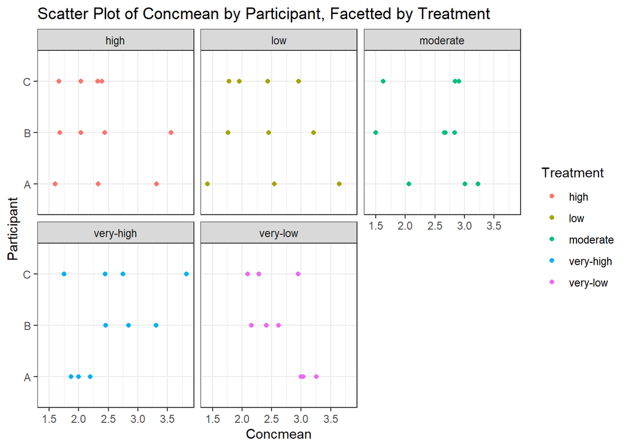

```r
Graph5 <- ggplot(data = changedcombined_df,
                 mapping = aes(x = Concmean, y = Participant,
                               color = Treatment)) + geom_point() +
  facet_wrap(~ Treatment) + theme_bw() +
  labs(title = "Scatter Plot of Concmean by Participant, Facetted by Treatment",
       x = "Concmean", y = "Participant")
Graph5
```

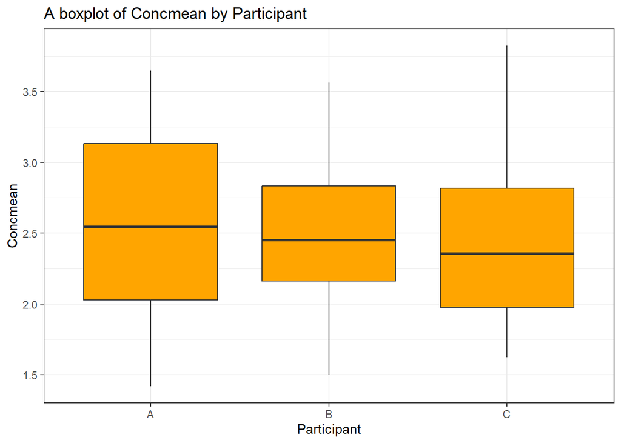

```r
Graph6 <- ggplot(data = changedcombined_df,
                 mapping = aes(x = Participant, y = Concmean)) +
  geom_boxplot(fill = "orange") + theme_bw() +
  labs(title = "A boxplot of Concmean by Participant",
       x = "Participant", y = "Concmean" )
Graph6
```

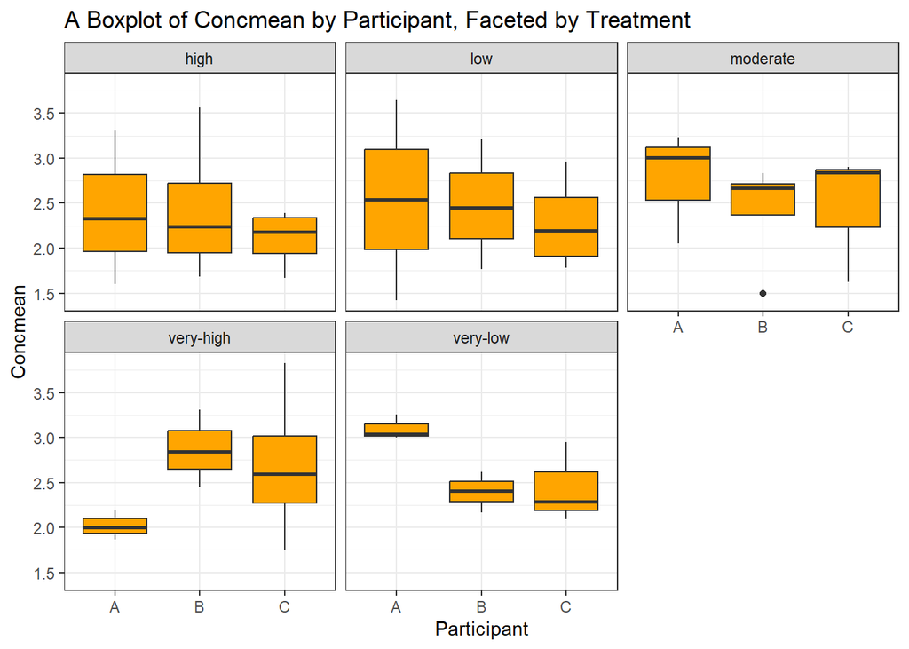

```r
Graph7 <- ggplot(data = changedcombined_df,
                 mapping = aes(x = Participant, y = Concmean)) +
  geom_boxplot(fill = "orange") + theme_bw() + facet_wrap(~ Treatment) +
  labs(title = "A Boxplot of Concmean by Participant, Faceted by Treatment",
       x = "Participant", y = "Concmean")
Graph7
```

```r
##saving images as png
ggsave("Graph1.png", Graph1)
ggsave("Graph2.png", Graph2)
ggsave("Graph3.png", Graph3)
ggsave("Graph4.png", Graph4)
ggsave("Graph5.png", Graph5)
ggsave("Graph6.png", Graph6)
ggsave("Graph7.png", Graph7)
```

# CLASSICAL HYPOTHESIS TESTING AND STATISTICAL MODELS IN R

## Importing statsFile into R.

```r
statsFile <- read.csv("statsFile.csv", header = TRUE, sep = ",")
knitr::kable(statsFile, align = "lllccc")
```

| X | BMI | BP | Gender | Status | Location |
| --- | --- | --- | --- | --- | --- |
| P_ 1 | 3.306331 | 1.848332 | Male | 1 | C |
| P_ 2 | 3.144198 | 1.803189 | Female | 0 | C |
| P_ 3 | 3.268586 | 1.837923 | Female | 1 | B |
| P_ 4 | 3.175555 | 1.812009 | Male | 1 | C |
| P_ 5 | 3.084312 | 1.786221 | Female | 1 | A |
| P_ 6 | 3.227014 | 1.826389 | Female | 1 | C |
| P_ 7 | 2.810668 | 1.706505 | Male | 1 | A |
| P_ 8 | 3.080841 | 1.785232 | Male | 1 | B |
| P_ 9 | 3.127907 | 1.798589 | Male | 1 | C |
| P_ 10 | 2.986719 | 1.758213 | Female | 1 | B |
| P_ 11 | 2.877521 | 1.726326 | Female | 0 | B |
| P_ 12 | 3.059652 | 1.779186 | Female | 1 | B |
| P_ 13 | 2.984433 | 1.757551 | Female | 0 | B |
| P_ 14 | 3.425849 | 1.880905 | Male | 1 | B |
| P_ 15 | 3.439004 | 1.884455 | Male | 1 | B |
| P_ 16 | 3.428063 | 1.881503 | Female | 1 | B |
| P_ 17 | 3.122743 | 1.797128 | Female | 0 | B |
| P_ 18 | 2.978352 | 1.755790 | Male | 0 | C |
| P_ 19 | 2.938889 | 1.744319 | Male | 1 | B |
| P_ 20 | 3.179976 | 1.813249 | Male | 0 | C |
| P_ 21 | 3.127935 | 1.798597 | Male | 1 | B |
| P_ 22 | 3.274198 | 1.839474 | Female | 1 | B |
| P_ 23 | 2.963454 | 1.751469 | Male | 0 | A |
| P_ 24 | 3.445759 | 1.886276 | Female | 0 | B |
| P_ 25 | 3.228358 | 1.826763 | Female | 1 | C |
| P_ 26 | 2.840086 | 1.715256 | Female | 0 | C |
| P_ 27 | 3.281707 | 1.841548 | Male | 1 | C |
| P_ 28 | 3.273761 | 1.839354 | Male | 0 | B |
| P_ 29 | 3.279747 | 1.841007 | Male | 0 | B |
| P_ 30 | 3.257726 | 1.834917 | Male | 1 | A |

[output cut: 290 more lines]

### How BMI relates to BP for the all study participants;

A correlation test was performed using the procedures indicated below to evaluate the relationship between the two variables (BMI and BP) in order to assess trends. A Pearson correlation test was used to determine the correlation coefficient between two quantitative variables (BMI and BP). The correlation coefficient, which runs from -1 to 1, is a symmetric measure of relationship between two variables. The covariance method and the cor.test() method were used to compute the correlation coefficient. The covariance expresses how much BMI and BP “change together” and whether their relationship is positive or negative. The correlation allows us to further analyze the covariance by identifying both the direction and degree of the link. Cor.test() for Pearson correlation is used for quantitative continuous variables with a linear relationship and returns the Pearson’s product-moment correlation coefficient.

```r
library(ggplot2)

#calcuating correlation coefficient using covariance
cov(statsFile$BMI, statsFile$BP)
```

```
## [1] 0.01065146
```

```r
cov(statsFile$BMI, statsFile$BP)/(sd(statsFile$BMI)*sd(statsFile$BP))
```

```
## [1] 0.9997509
```

```r
#OR directly using correlation test
cor.test(statsFile$BMI, statsFile$BP)
```

```
##
##  Pearson's product-moment correlation
##
## data:  statsFile$BMI and statsFile$BP
## t = 798.75, df = 318, p-value < 2.2e-16
## alternative hypothesis: true correlation is not equal to 0
## 95 percent confidence interval:
##  0.9996895 0.9998001
## sample estimates:
##       cor
## 0.9997509
```

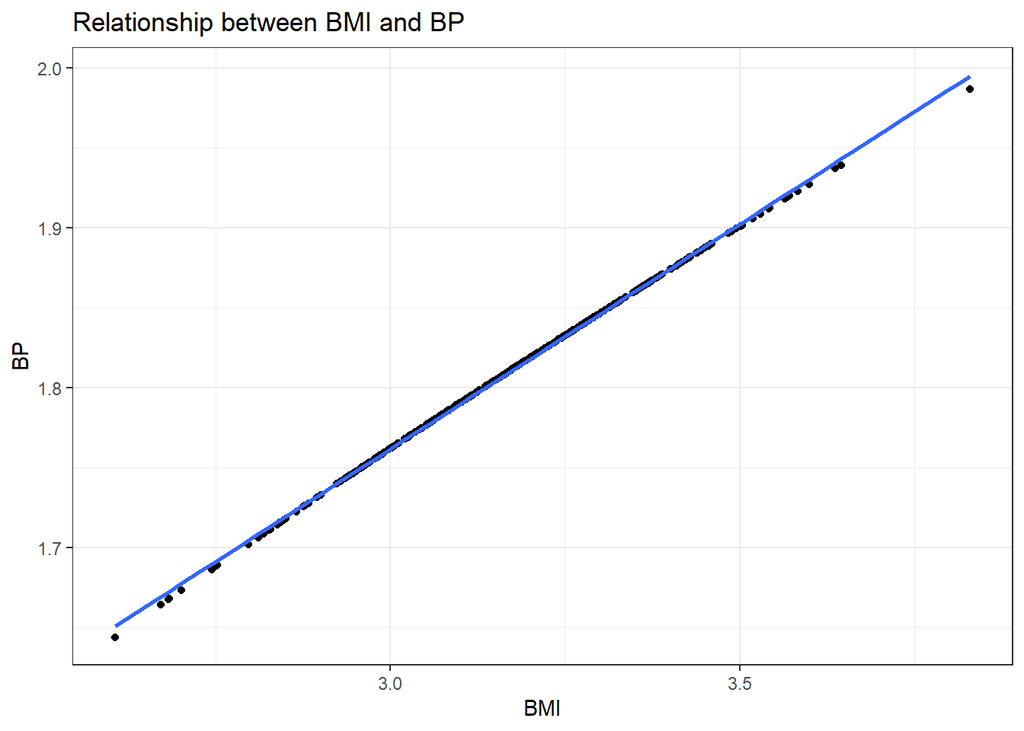

```r
#plot for visualization of the relationship
ggplot(statsFile, mapping = aes(x = BMI, y = BP)) +
  geom_point() + geom_smooth(method = 'lm', formula = y ~ x) +
  theme_bw() + labs(title = "Relationship between BMI and BP", x = "BMI", y = "BP")
```

### Results Interpretation

**Covariance and Correlation** : Because the nature of the relationship between BMI and BP is positive (*a positive covariance value*), when BMI rises, so does BP. BMI and blood pressure showed a strong positive linear association, according to the correlation coefficient of 0.9997509. Subsequently the significant covariance and correlation showed that BMI and BP have a strong positive linear association. The correlation coefficient was almost exactly one, showing a nearly perfect positive linear relationship.

**Correlation test** : The Pearson’s product-moment correlation result yielded a p value less than 0.05, indicating statistical significance and allowing the null hypothesis of “true correlation equals 0” to be rejected. The correlation coefficient had a 95% confidence interval of 0.9996895 to 0.9998001. It lacked the null value, indicating statistical significance and so null hypothesis rejection. In conclusion, the correlation test confirmed the substantial positive linear association between BMI and BP.

**Scatter plot** : As a best practice, this relationship was also depicted using a scatter plot.The scatter plot depicted the association between BMI and BP. Visualization with a scatter plot also assisted us in determining whether we had any outliers that could significantly skew the correlation coefficient. The outliers observed here didn’t drastically change our correlation but they should be further investigated. The **geom_smooth()** function added a linear regression line to the plot, indicating the strength and direction of the link.

**Furthermore**, to compare the two samples, we used a measure of central tendency computed for each sample (in this case, the mean). A Student’s t-test for unpaired samples was used to assess whether the means of two independent samples are significantly different. An F test was used to compare the variances of BMI and BP, as shown below.

```r
#Comparison of the means
meanBMI_BP <- sapply(statsFile[2:3], mean)
meanBMI_BP
```

```
##      BMI       BP
## 3.185907 1.814074
```

```r
mean_comparison <- t.test(statsFile$BMI, statsFile$BP) #student's t-test to compare means
mean_comparison
```

```
##
##  Welch Two Sample t-test
##
## data:  statsFile$BMI and statsFile$BP
## t = 121.36, df = 369.13, p-value < 2.2e-16
## alternative hypothesis: true difference in means is not equal to 0
## 95 percent confidence interval:
##  1.349605 1.394060
## sample estimates:
## mean of x mean of y
##  3.185907  1.814074
```

```r
#Comparison of the variances
varianceBMI_BP <- sapply(statsFile[2:3], var)
varianceBMI_BP
```

```
##         BMI          BP
## 0.037890841 0.002995712
```

```r
variance_comparison <- var.test(statsFile$BMI, statsFile$BP) #F test to compare two variances
variance_comparison
```

```
##
##  F test to compare two variances
##
## data:  statsFile$BMI and statsFile$BP
## F = 12.648, num df = 319, denom df = 319, p-value < 2.2e-16
## alternative hypothesis: true ratio of variances is not equal to 1
## 95 percent confidence interval:
##  10.15190 15.75872
## sample estimates:
## ratio of variances
##           12.64836
```

### Results Interpretation

**Student t-test results** : To understand the preceding findings, we first determined the individual means of the variables BMI and BP. The Student’s t-test was performed on the assumption that these are independent variables and that there is no difference between the means of BMI and BP, i.e. “the true difference in means is equal to 0” as our null hypothesis. Because the p value is 2.2e-16, we reject the null hypothesis of equal means at the 5% level of significance. The results provided adequate evidence to reject the hypothesis that there is no difference between the means of BMI and BP. The null value was not contained in the 95% confidence range, indicating statistical significance. Moreover, the t-value of 121.36 represents the difference in standard deviations between the means of the two groups. A bigger absolute t-value implied that the difference between the groups is more significant. Ultimately, the BMI and BP means diverge, and this difference is statistically significant.

**F-test results** : For the comparison of the two variances, our null hypothesis was that the true ratio of variances is equal to one. Based on this assumption, the F test revealed that the ratio of variances obtained was 12.64836, which is clearly not equal to one. Nonetheless, the p-value was less than 0.05, indicating statistical significance and thus rejection of the null hypothesis, and this also verifies the results obtained by computing the individual variances of BMI and BP. Subsequently the F test indicates a substantial difference in variances between BMI and BP. The p-value obtained was quite low, indicating that the null hypothesis of equal variances could be rejected. The ratio of variances’ confidence interval didn’t include 1, further supporting the conclusion that the variances were significantly different.

### How disease status (phenotype) is related to gender;

A statistical test appropriate for categorical or qualitative variables was employed to investigate the relation between disease and gender. This is referred to as the Chi-square test of independence. The Chi-square test of independence compares observed frequencies (those in your sample) to expected frequencies if there is no association between the two categorical variables (those expected if the null hypothesis is true). The null hypothesis for the Chi-square test of independence is that no association exists between the two categorical variables (Disease Status and Gender), implying that these variables are independent. The alternative hypothesis is that there is a link, and hence the variables are dependent on one another.

```r
##creation of contingency tables
contigency_table <- table(statsFile$Status, statsFile$Gender)
contigency_table
```

```
##
##     Female Male
##   0    100   65
##   1     85   70
```

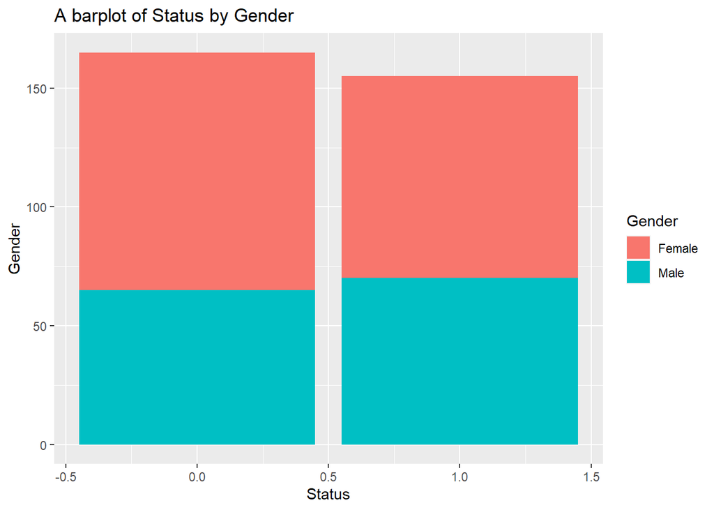

```r
##visualization of distribution using a bar plot
library(ggplot2)
ggplot(statsFile, aes(x = Status, fill = Gender)) + geom_bar() +
  labs(title = "A barplot of Status by Gender", x = "Status", y = "Gender" )
```

```r
chisq.test(contigency_table)
```

```
##
##  Pearson's Chi-squared test with Yates' continuity correction
##
## data:  contigency_table
## X-squared = 0.86632, df = 1, p-value = 0.352
```

### Results Interpretation

To analyze these results, first a contingency table was created that showed the observed number of individuals with the disease or not; based on their gender. This could also be represented with a bar graph of the disease status filled by Gender(“Male” or “Female”). The p value from the Pearson’s Chi-squared test was 0.352, so at the 5% significance level, we failed to reject the null hypothesis, indicating that there was no significant relationship between disease status and gender and that there is insufficient evidence to suggest that gender and disease status are associated. As a result, this was consistent with the premise that disease condition and gender are unrelated.

### Constructing an appropriate model to show the relationship between BMI and BP;

We used regression analysis to build a model that demonstrated the link between BMI and BP. Specifically, a simple linear regression model to describe the effect of a specific variable on the value of a continuous outcome variable, known as the response variable. We wanted to model a quantitative response variable (BP) as a function of a predictor variable (BMI) in this scenario.

```r
fit.model <- lm(BP ~ BMI, data = statsFile)
summary(fit.model)
```

```
##
## Call:
## lm(formula = BP ~ BMI, data = statsFile)
##
## Residuals:
##        Min         1Q     Median         3Q        Max
## -0.0080845 -0.0001705  0.0004430  0.0007507  0.0008477
##
## Coefficients:
##              Estimate Std. Error t value Pr(>|t|)
## (Intercept) 0.9184871  0.0011233   817.6   <2e-16 ***
## BMI         0.2811090  0.0003519   798.7   <2e-16 ***
## ---
## Signif. codes:  0 '***' 0.001 '**' 0.01 '*' 0.05 '.' 0.1 ' ' 1
##
## Residual standard error: 0.001224 on 318 degrees of freedom
## Multiple R-squared:  0.9995, Adjusted R-squared:  0.9995
## F-statistic: 6.38e+05 on 1 and 318 DF,  p-value: < 2.2e-16
```

### Results Interpretation

The **lm()** function was used to create a linear regression model with BP as the dependent variable and BMI as the independent variable to interpret the findings. Summary() returned detailed information about the regression model, such as coefficients, R-squared values, and p-values. Based on the coefficients, the model equation is as follows: BP = 0.9185 + 0.2811 * BMI. In this scenario, the intercept indicates the expected BP when BMI is zero. Both the intercept and BMI coefficients were highly significant (*** in the Signif. codes). This showed that the link between BMI and BP was statistically significant. The statistical significance could also be seen by examining the p-value, which was less than 0.05. This extremely low p-value indicated that the entire model is highly significant. The F-statistic was also used to assess the model’s overall significance. The R-squared values represent the proportion of BP variance explained by BMI variance, and high R-squared values of 0.9995 implied a better fit. This simple regression model implied a linear relationship, which we saw in our correlation test earlier. So, in our data set, this linear regression model suggested a robust and very significant positive connection between BMI and BP.

### How BMI compares in the different sampling locations;

We employed descriptive statistics and a statistical test to compare BMI in different sampling areas. Because we have two variables, one quantitative (BMI) and one qualitative (sampling locations), we used a one-way ANOVA (Analysis of Variance) test for statistical analysis, assuming that these are independent variables that are parametric (normally distributed) and have equal population variances. A one-way ANOVA (Analysis of Variance) compared the three location groups to see if there is any significant differences between them.

```r
library(dplyr)
library(ggplot2)

##dataframe of BMI and sampling location
BMI_locations <- data.frame(statsFile$BMI, statsFile$Location)
knitr::kable(BMI_locations, align = "cc")
```

| statsFile.BMI | statsFile.Location |
| --- | --- |
| 3.306331 | C |
| 3.144198 | C |
| 3.268586 | B |
| 3.175555 | C |
| 3.084312 | A |
| 3.227014 | C |
| 2.810668 | A |
| 3.080841 | B |
| 3.127907 | C |
| 2.986719 | B |
| 2.877521 | B |
| 3.059652 | B |
| 2.984433 | B |
| 3.425849 | B |
| 3.439004 | B |
| 3.428063 | B |
| 3.122743 | B |
| 2.978352 | C |
| 2.938889 | B |
| 3.179976 | C |
| 3.127935 | B |
| 3.274198 | B |
| 2.963454 | A |
| 3.445759 | B |
| 3.228358 | C |
| 2.840086 | C |
| 3.281707 | C |
| 3.273761 | B |
| 3.279747 | B |
| 3.257726 | A |

[output cut: 290 more lines]

```r
##calculating mean, median and standard deviation
BMI_locations %>%
  group_by(statsFile.Location) %>%
  summarise(mean(statsFile.BMI), median(statsFile.BMI), sd(statsFile.BMI))
```

| statsFile.Location | mean(statsFile.BMI) | median(statsFile.BMI) | sd(statsFile.BMI) |
| --- | --- | --- | --- |
| A | 3.177883 | 3.206107 | 0.1919685 |
| B | 3.207686 | 3.194558 | 0.1988717 |
| C | 3.168441 | 3.170888 | 0.1916021 |

```r
##calculating the variance
BMI_locations %>%
  group_by(statsFile.Location) %>%
  summarise(var(statsFile.BMI))
```

| statsFile.Location | var(statsFile.BMI) |
| --- | --- |
| A | 0.03685191 |
| B | 0.03954995 |
| C | 0.03671136 |

```r
##summary stats
summary(statsFile$BMI)
```

```
##    Min. 1st Qu.  Median    Mean 3rd Qu.    Max.
##   2.606   3.057   3.190   3.186   3.319   3.830
```

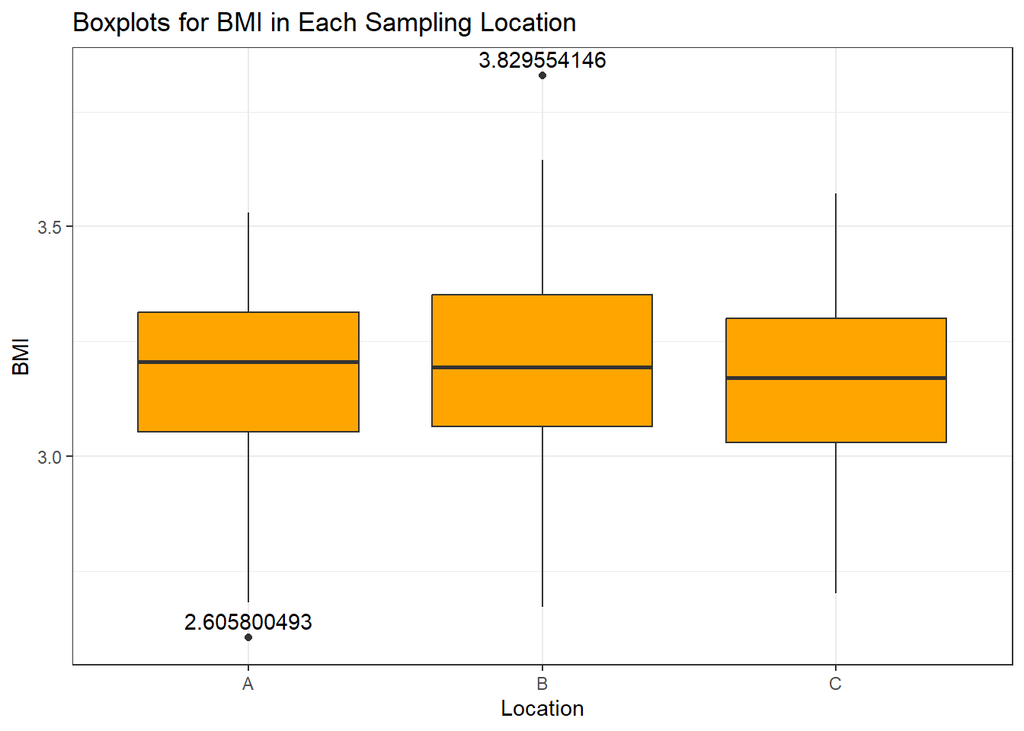

```r
##visualization(box plot, scatter plot and histogram)
ggplot(data = statsFile, aes(x = Location, y = BMI)) +
  geom_boxplot(fill = "orange") +
  theme_bw() +
  geom_text(aes(label = ifelse(BMI > (quantile(BMI)[4] + 1.5 * IQR(BMI)) |
                                 BMI < (quantile(BMI)[2] - 1.5 * IQR(BMI)),
                               as.character(BMI), "")),
            position = position_dodge(width = 0.75), vjust = -0.5) +
  labs(title = "Boxplots for BMI in Each Sampling Location",
       x = "Location",
       y = "BMI")
```

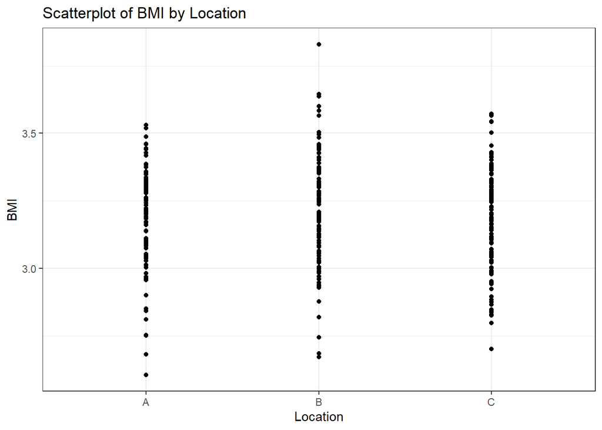

```r
ggplot(statsFile, mapping = aes(x = Location, y = BMI)) + geom_point() +
 theme_bw() + labs(title = "Scatterplot of BMI by Location", x = "Location", y = "BMI")
```

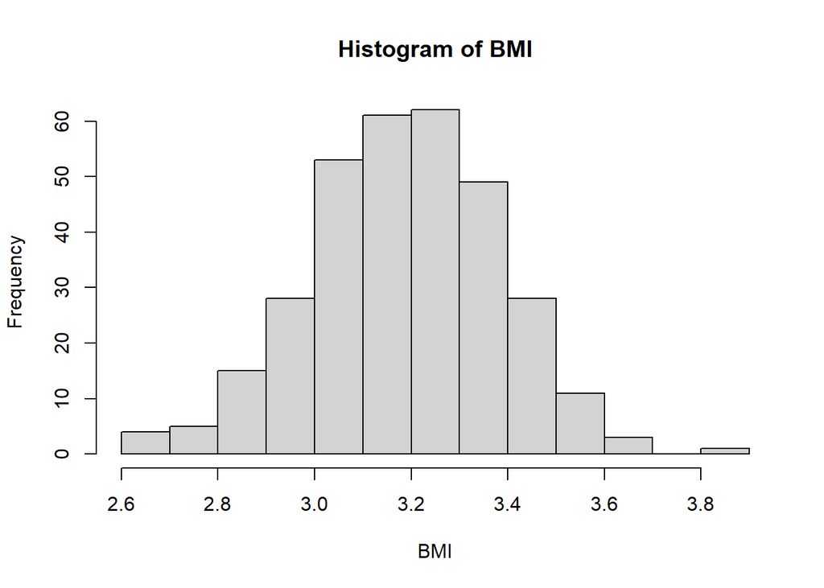

```r
hist(statsFile$BMI, main = "Histogram of BMI", xlab = "BMI")
```

```r
##statistical test; one way ANOVA
comparison <- aov(BMI ~ Location, data = statsFile)
summary(comparison)
```

```
##              Df Sum Sq Mean Sq F value Pr(>F)
## Location      2  0.097 0.04834   1.278   0.28
## Residuals   317 11.991 0.03782
```

### Results Interpretation

**The mean and median** were determined to describe the centrality of the numeric observations of BMI per different sampling locations (“A”, “B”, and “C”). The typical BMI values for locations A, B, and C ranged from 3.17 to 3.21. The medians were also close together, ranging from 3.17 to 3.21. These results provided a snapshot of the data’s normal distribution. Remember that the mean and median of normally distributed data are equal. **The standard deviations** obtained were relatively small, showing that BMI levels are relatively consistent within each sampling location.

**The variance** of BMI for the different locations were remarkably similar; confirming the assumption of equal variances in order to perform a one-way ANOVA test. The closeness in these variances was also highlighted further by visualization. Furthermore, the summary of the entire dataset shows a range of BMI values from 2.606 to 3.830.

**Visualization**: The boxplot is an excellent tool for visualizing the distribution of a BMI over various sampling locations. Two outliers were found, one at Location “A” and one at Location “B.” These outliers should ideally be investigated, but in this situation, ANOVA is more robust and will not be influenced by outliers. It could also be seen that the box and whiskers are comparable across all sites. The scatter plot showed that the points for all of the different sites were nearly identical, indicating that the variance is quite comparable. The histogram indicated that the normalcy assumption appeared to be met. Moreover, the histogram resembled a bell curve, indicating that the data should be normally distributed.

**One-way ANOVA** : Based on the assumptions, the aov() function was used to test the null hypothesis that “there is no significant difference in the mean BMI values among the three sampling locations.” In other words, the average BMI is the same across all sampling locations. The p-value reported was 0.28, indicating that there is no statistical significance and hence we cannot reject the null hypothesis. This suggested that the location effect was not statistically significant and also very tiny (F = 1.278). In conclusion, there’s insufficient evidence to conclude that there’s a substantial variation in mean BMI values among the three sampling locations based on the data.

### How disease status depends on both BMI and BP;

A useful statistical modeling approach for more than two variables was employed to understand how illness status can be influenced by both BMI and BP. Because disease status is the qualitative dependent variable in this situation, and an individual either has or does not have the disease, a binary logistic regression model was built for this investigation. Logistic regression is appropriate for binary outcomes like illness status (yes/no).

```r
dependency <- glm(Status ~ BMI + BP,
                  data = statsFile, family = binomial)
summary(dependency)
```

```
##
## Call:
## glm(formula = Status ~ BMI + BP, family = binomial, data = statsFile)
##
## Coefficients:
##             Estimate Std. Error z value Pr(>|z|)
## (Intercept)   -11.64      84.53  -0.138    0.890
## BMI            -4.15      25.88  -0.160    0.873
## BP             13.67      92.02   0.149    0.882
##
## (Dispersion parameter for binomial family taken to be 1)
##
##     Null deviance: 443.30  on 319  degrees of freedom
## Residual deviance: 442.99  on 317  degrees of freedom
## AIC: 448.99
##
## Number of Fisher Scoring iterations: 3
```

### Results Interpretation

From the code above, the dependent variable was “Status” (disease status), and the independent variables were “BMI” and “BP.” The family = “binomial” argument specified the logistic regression model. The **summary()** provided more detailed information about coefficients, p-values and so on. Looking at the coefficients;

**Intercept** : this represents the estimated log-odds of the baseline category (e.g., disease status = 0) when both BMI and BP are zero. The intercept in this case was not statistically significant (p-value = 0.890), and the estimate was -11.64.

**BMI** : The coefficient for BMI obtained was -4.15. It thus indicated the change in the log-odds of the disease for a one-unit increase in BMI while holding BP constant. However, the coefficient was not statistically significant (p-value = 0.873), suggesting that BMI is not a significant predictor of disease status in this model.

**BP** : The coefficient for BP was 13.67. It represented the change in the log-odds of the disease for a one-unit increase in BP while holding BMI constant. Similar to BMI, the coefficient for BP was not statistically significant (p-value = 0.882), indicating that BP is not a significant predictor of disease status in this model.

**Number of Fisher Scoring Iterations** is 3 indicating three iterations the algorithm went through to estimate the coefficients.

In conclusion, based on the p-values, BMI and BP appeared to be statistically non-significant predictors of disease status in this logistic regression model. It is therefore suggested that there was no evidence of a relationship between BMI, BP, and disease status.